From Data to Dollars: Predicting Amazon stock prices with Technical and Economic Indicators and Strategy

# Introduction

The stock market is a complex and dynamic system. Stocks are heavily influenced by a company's performance, macroeconomic trends, geopolitics, etc. Due to the nature of stocks, it is highly volatile and we see predicting stock fluctuations with high accuracy remains one of the most challenging problems in finance. Therefore, making stock price prediction a challenging yet captivating endeavor. This project aims to predict the direction (up or down) of Amazon's stock price using machine learning techniques. We seek to answer the following questions: Can we accurately predict whether Amazon's stock price will increase or decrease in the next week based on historical data? Which features are most influential in driving these predictions? Answering these questions is crucial for investors as accurate predictions can provide valuable insights for informed trading decisions and potentially lead to profitable outcomes. The goal of the tutorial is to demonstrate the feasibility, complexity, and limitations of using machine learning models for stock trading—showing that while such models can offer predictive insights, turning those insights into reliable, profitable trading strategies demands significant effort, careful feature engineering, domain expertise, and rigorous backtesting.

# Data Curation

The project utilizes data from three sources:

Amazon Stock Data: Historical stock prices (open, high, low, close, adjusted close, and volume) for Amazon were obtained from Kaggle.

Interest Rates: Data on federal funds effective rate (FEDFUNDS) was retrieved from the Federal Reserve Economic Data (FRED) using pandas_datareader.data.

10-Year Treasury Yield: Data for the 10-Year Treasury Constant Maturity Rate (DGS10) was also downloaded from FRED.

The data was then transformed and prepared for analysis. This involved resampling to weekly frequency, aligning data points, calculating new features like moving averages, relative strength index (RSI), volatility, and momentum, and handling missing values. The resulting dataset was organized into a pandas DataFrame, data, containing the features and the target variable (price direction).

This project uses three main sources of data to help predict Amazon’s stock movement. First, it looks at Amazon’s past stock prices—such as daily opening, closing, highest, and lowest prices, along with trading volume—to understand how the stock has behaved over time. Next, it includes interest rate data from the U.S. Federal Reserve, since changes in interest rates can affect how investors make decisions. Finally, it uses the 10-year Treasury yield, which reflects how confident investors are about the economy. All of this data is cleaned up, combined, and turned into useful measurements—like how much the price has moved recently or how volatile it is—so that a machine learning model can try to learn patterns and make predictions. The goal is to give the model not just a snapshot of Amazon, but also some broader economic context.

# Methodology

Our analysis follows a structured machine learning workflow designed to predict stock price direction based on historical and technical indicators. We begin by engineering a range of features—including rolling averages, RSI, volatility, momentum, and lagged returns—from weekly Amazon stock data. After preprocessing and scaling, we split the dataset into training and testing subsets to evaluate out-of-sample generalization.

```python
import pandas as pd
import matplotlib.pyplot as plt
import numpy as np
import sklearn as sk
import kagglehub
import pandas_datareader.data as web

path = kagglehub.dataset_download("umerhaddii/amazon-stock-data-2025", path='AMZN_1997-05-15_2025-02-21.csv')
dataframe = pd.read_csv(path)
interest_rates = web.DataReader('FEDFUNDS', 'fred', start='1997-05-15', end='2025-02-21')
interest_rates = interest_rates.resample('D').ffill()
interest_rates.index = interest_rates.index.tz_localize('UTC')
dataframe['date'] = pd.to_datetime(dataframe['date'], utc=True)
dataframe.set_index('date', inplace=True)
# Define the URL for the CSV data
url = 'https://fred.stlouisfed.org/graph/fredgraph.csv?id=DGS10'

# Read the CSV data into a pandas DataFrame
df = pd.read_csv(url)

# Convert the 'DATE' column to datetime format
df['observation_date'] = pd.to_datetime(df['observation_date'])

# Rename columns for clarity
df.rename(columns={'observation_date': 'Date', 'DGS10': '10Y_Yield'}, inplace=True)

# Set 'Date' as the index
df.set_index('Date', inplace=True)

# Convert yield values to numeric, coercing errors to NaN
df['10Y_Yield'] = pd.to_numeric(df['10Y_Yield'], errors='coerce')

# Drop rows with missing values
df.dropna(inplace=True)

# Display the first few rows
df.head()
dataframe.columns
```

```
Index(['open', 'high', 'low', 'close', 'adj_close', 'volume'], dtype='object')
```

Visualization of the dataset

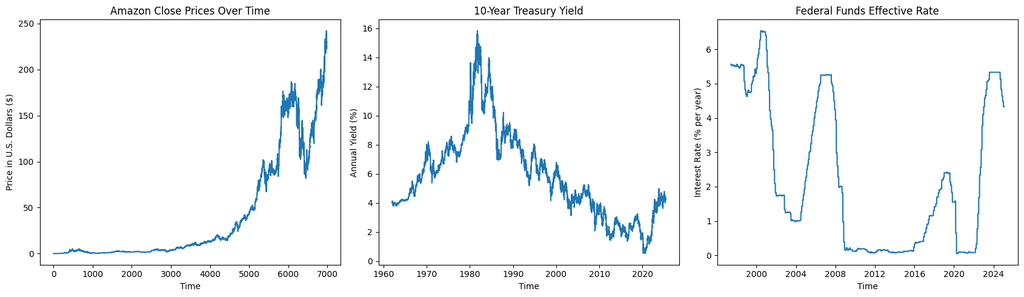

```python
fig, axs = plt.subplots(1, 3, figsize=(17, 5))

# Plot 1: Amazon close prices
axs[0].plot(dataframe['close'])
axs[0].set_title("Amazon Close Prices Over Time")
axs[0].set_xlabel("Time")
axs[0].set_ylabel("Price in U.S. Dollars ($)")

# Plot 2: 10-Year Treasury Yield
axs[1].plot(df['10Y_Yield'])
axs[1].set_title("10-Year Treasury Yield")
axs[1].set_xlabel("Time")
axs[1].set_ylabel("Annual Yield (%)")

# Plot 3: Federal Funds Rate
axs[2].plot(interest_rates['FEDFUNDS'])
axs[2].set_title("Federal Funds Effective Rate")
axs[2].set_xlabel("Time")
axs[2].set_ylabel("Interest Rate (% per year)")

plt.tight_layout()
plt.show()
```

```python
# Resample to weekly frequency, taking the last available yield of each week
weekly_treasury_df = df.resample('W').last()
weekly_treasury_df = weekly_treasury_df.loc['1997-05-15':'2025-02-21']

# Display the first few rows of the weekly data
weekly_treasury_df.head()
```

| Date | 10Y_Yield |
| --- | --- |
| 1997-05-18 | 6.70 |
| 1997-05-25 | 6.74 |
| 1997-06-01 | 6.67 |
| 1997-06-08 | 6.51 |
| 1997-06-15 | 6.43 |

```python
# Resample to weekly frequency ending on Friday
amzn_weekly = dataframe.resample('W').agg({
    'open': 'first',
    'high': 'max',
    'low': 'min',
    'close': 'last',
    'adj_close': 'last',
    'volume': 'sum'
})
```

```python
# Resample interest rates to weekly frequency using the last available value of each week
interest_rates_weekly = interest_rates.resample('W').last()

# Remove timezone info to avoid merge/concat issues
amzn_weekly.index = amzn_weekly.index.tz_localize(None)
interest_rates_weekly.index = interest_rates_weekly.index.tz_localize(None)
weekly_treasury_df.index = weekly_treasury_df.index.tz_localize(None)

# Concatenate all DataFrames along columns and drop rows with any missing values
data = pd.concat([amzn_weekly, interest_rates_weekly, weekly_treasury_df], axis=1).dropna()

# Rename columns for clarity (make sure you match the number of columns!)
data.columns = [
    'open', 'high', 'low', 'close', 'adj_close', 'volume',
    'interest_rate', '10Y_treasury_yield'
]

(data.head())
```

|  | open | high | low | close | adj_close | volume | interest_rate | 10Y_treasury_yield |
| --- | --- | --- | --- | --- | --- | --- | --- | --- |
| 1997-06-01 | 0.075521 | 0.082292 | 0.072917 | 0.075000 | 0.075000 | 386784000 | 5.56 | 6.67 |
| 1997-06-08 | 0.075521 | 0.085417 | 0.068750 | 0.082813 | 0.082813 | 366696000 | 5.56 | 6.51 |
| 1997-06-15 | 0.082813 | 0.085417 | 0.076563 | 0.079167 | 0.079167 | 226488000 | 5.56 | 6.43 |
| 1997-06-22 | 0.080208 | 0.080208 | 0.074740 | 0.076302 | 0.076302 | 249504000 | 5.56 | 6.37 |
| 1997-06-29 | 0.077083 | 0.077083 | 0.073958 | 0.074479 | 0.074479 | 165648000 | 5.56 | 6.46 |

```python
data['Interest_Rate_Change'] = data['interest_rate'].pct_change()
data.head(5)
```

|  | open | high | low | close | adj_close | volume | interest_rate | 10Y_treasury_yield | Interest_Rate_Change |
| --- | --- | --- | --- | --- | --- | --- | --- | --- | --- |
| 1997-06-01 | 0.075521 | 0.082292 | 0.072917 | 0.075000 | 0.075000 | 386784000 | 5.56 | 6.67 | NaN |
| 1997-06-08 | 0.075521 | 0.085417 | 0.068750 | 0.082813 | 0.082813 | 366696000 | 5.56 | 6.51 | 0.0 |
| 1997-06-15 | 0.082813 | 0.085417 | 0.076563 | 0.079167 | 0.079167 | 226488000 | 5.56 | 6.43 | 0.0 |
| 1997-06-22 | 0.080208 | 0.080208 | 0.074740 | 0.076302 | 0.076302 | 249504000 | 5.56 | 6.37 | 0.0 |
| 1997-06-29 | 0.077083 | 0.077083 | 0.073958 | 0.074479 | 0.074479 | 165648000 | 5.56 | 6.46 | 0.0 |

The line data['Price_Direction'] = data['adj_close'].shift(-1) > data['adj_close'] creates a binary target variable that captures whether the stock's price increases in the next time step. By shifting the adjusted close price one step backward, we align tomorrow’s (in this case next week's) price with today’s (this week's) features—enabling the model to learn patterns that precede upward or downward movements.

This transformation is essential for supervised learning, where the goal is to predict a future outcome (next period's movement) using present data (this period's features). Without this shift, the model would inadvertently "see the future" and train on data it wouldn’t have access to in real-world deployment, leading to information leakage and unrealistic performance.

Converting the result to an integer (1 for upward movement, 0 otherwise) ensures compatibility with classification algorithms. The final step, dropping the resulting NaN, is necessary since the last row has no “tomorrow” to compare with.

```python
data['Price_Direction'] = data['adj_close'].shift(-1) > data['adj_close']
# chacking if tomorrow's price is greater than today's price. If so, the price direction will be 1, if not the price direction will be 0.
# this saves the price direction column. An obvious consequence is that the last row will be a NaN, tere for it is deleted below.
data['Price_Direction'] = data['Price_Direction'].astype(int) # we want int instead of bool to use in machine learning.
data.dropna(inplace=True)
data.tail(5)
```

|  | open | high | low | close | adj_close | volume | interest_rate | 10Y_treasury_yield | Interest_Rate_Change | Price_Direction |
| --- | --- | --- | --- | --- | --- | --- | --- | --- | --- | --- |
| 2025-01-05 | 220.059998 | 225.360001 | 218.190002 | 224.190002 | 224.190002 | 114613100 | 4.33 | 4.60 | -0.033482 | 0 |
| 2025-01-12 | 226.779999 | 228.839996 | 216.500000 | 218.940002 | 218.940002 | 121778800 | 4.33 | 4.77 | 0.000000 | 1 |
| 2025-01-19 | 218.059998 | 226.509995 | 216.199997 | 225.940002 | 225.940002 | 150393100 | 4.33 | 4.61 | 0.000000 | 1 |
| 2025-01-26 | 228.899994 | 236.399994 | 226.940002 | 234.850006 | 234.850006 | 133694800 | 4.33 | 4.63 | 0.000000 | 1 |
| 2025-02-02 | 226.210007 | 241.770004 | 225.860001 | 237.679993 | 237.679993 | 185290300 | 4.33 | 4.58 | 0.000000 | 0 |

# 2. Exploratory Data Analysis

Exploratory data analysis was conducted to gain initial insights into the dataset. Summary statistics were computed using data.describe() to understand the distribution and ranges of different features. A correlation matrix was generated using data.corr() and visualized using a heatmap, and boxplots to identify potential relationships between features. Time series plots of the closing price were created to observe trends and patterns over time.

In this step, we engineered a set of derived features to give the model more structure and signal beyond raw price inputs. The idea was to help the classifier detect patterns in how the stock behaves over time—such as trend direction, price variability, and potential reversals—by using simplified statistical summaries that are commonly used in market analysis.

We created features like price range (daily high minus low), volatility (standard deviation over a short window), and momentum (change in average price over a few weeks). These are straightforward transformations that highlight dynamics like uncertainty, acceleration, or stagnation in the stock’s movement—signal types that may correlate with short-term direction changes.

We also included RSI (Relative Strength Index), a normalized metric based on recent gains and losses that ranges from 0 to 100. While it comes from traditional trading heuristics, we’re not treating it as a guaranteed predictor. Instead, we’re using it as a compact feature that may encode useful signal—specifically, whether recent price trends are accelerating or overextended. It’s one way to surface behavioral patterns in the data that might help the model anticipate short-term reversals or continuations.

Furthermore, we visualized the correlation matrix to check for redundancy between features. Highly correlated variables can reduce generalization, so we use this step to flag potential overlap even if we don’t immediately drop any features. Boxplots were created for the high, low, and close prices to visually examine their distributions. All three plots showed very similar shapes and spreads, reinforcing the earlier correlation findings that these price types move almost identically. The medians were clustered near the lower end of each box, while the whiskers extended upward with a large number of high-value outliers. This indicates that most prices were historically low, but the stock saw significant growth over time, resulting in many high-price outliers. The visual similarity between the plots confirms that using just one price type—such as the closing price—is sufficient for modeling, as the others provide redundant information.

Overall, the goal of this feature engineering step was to capture meaningful patterns in the stock’s recent behavior using simple, easy-to-understand calculations. We focused on building features that highlight trends and movement without needing deep knowledge of financial theory. This makes the model easier to understand, easier to work with, and more flexible for anyone building or improving it.

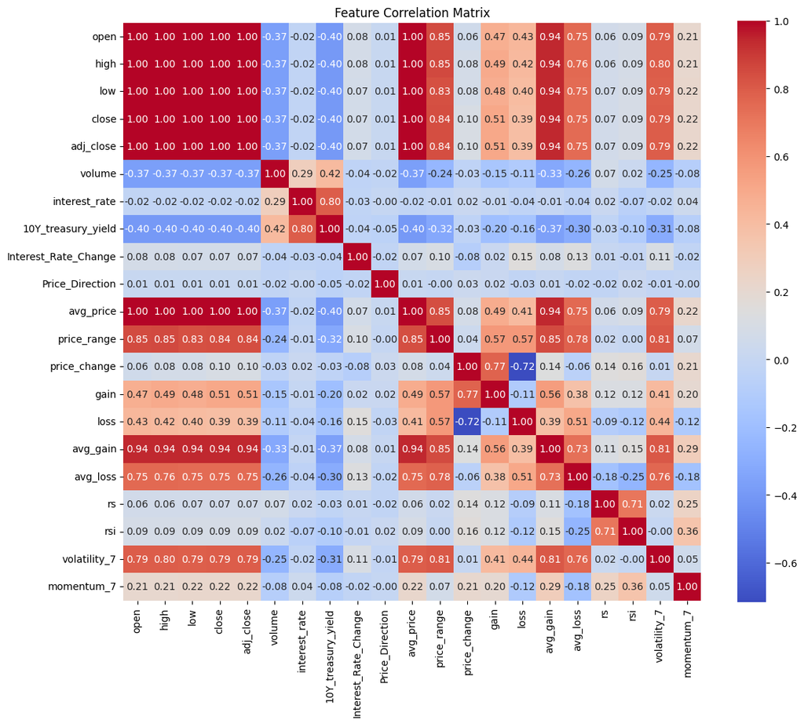

```
High Price Mean:          $41.14
High Price Median:        $9.16
High Price SD:            $58.75
High Price Range:         $242.45
High Price Minimum:       $0.07
High Price Maximum:       $242.52

Low Price Mean:           $40.15
Low Price Median:         $8.92
Low Price SD:             $57.40
Low Price Range:          $237.96
Low Price Minimum:        $0.07
Low Price Maximum:        $238.03

Close Prices Mean:        $40.66
Close Prices Median:      $9.02
Close Prices SD:          $58.09
Close Prices Range:       $241.99
Close Prices Minimum:     $0.07
Close Prices Maximum:     $242.06
```

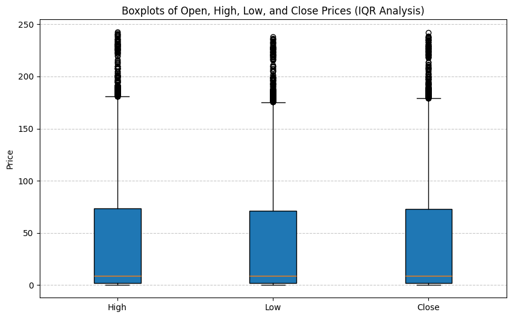

|  | open | high | low | close | adj_close | volume | interest_rate | 10Y_treasury_yield | Interest_Rate_Change | Price_Direction | ... | price_range | price_change | gain | loss | avg_gain | avg_loss | rs | rsi | volatility_7 | momentum_7 |
| --- | --- | --- | --- | --- | --- | --- | --- | --- | --- | --- | --- | --- | --- | --- | --- | --- | --- | --- | --- | --- | --- |
| count | 1430.000000 | 1430.000000 | 1430.000000 | 1430.000000 | 1430.000000 | 1.430000e+03 | 1430.000000 | 1430.000000 | 1430.000000 | 1430.000000 | ... | 1430.000000 | 1430.000000 | 1430.000000 | 1430.000000 | 1430.000000 | 1430.000000 | 1430.000000 | 1430.000000 | 1430.000000 | 1430.000000 |
| mean | 40.669031 | 42.026366 | 39.457397 | 40.841011 | 40.841011 | 6.592640e+08 | 2.204769 | 3.475336 | 0.004160 | 0.533566 | ... | 2.568969 | 0.166122 | 0.737381 | 0.571259 | 0.718612 | 0.565911 | 1.905396 | 57.097868 | 1.347933 | 0.790547 |
| std | 57.595904 | 59.450535 | 55.959271 | 57.834407 | 57.834407 | 5.644768e+08 | 2.139939 | 1.400929 | 0.091014 | 0.499047 | ... | 4.132812 | 2.898331 | 2.032546 | 1.850951 | 1.041641 | 0.974226 | 2.085549 | 16.660473 | 2.258108 | 6.132072 |
| min | 0.126563 | 0.184896 | 0.125000 | 0.181250 | 0.181250 | 8.659130e+07 | 0.050000 | 0.550000 | -0.923077 | 0.000000 | ... | 0.011979 | -20.068504 | 0.000000 | -0.000000 | 0.006883 | 0.000297 | 0.173782 | 14.805311 | 0.005536 | -50.109499 |
| 25% | 2.132500 | 2.261250 | 2.043125 | 2.147031 | 2.147031 | 3.227770e+08 | 0.160000 | 2.282500 | 0.000000 | 0.000000 | ... | 0.203812 | -0.197125 | 0.000000 | 0.000000 | 0.060929 | 0.052036 | 0.813450 | 44.856473 | 0.110044 | -0.253406 |
| 50% | 9.157000 | 9.420750 | 8.889750 | 9.173250 | 9.173250 | 5.123050e+08 | 1.550000 | 3.545000 | 0.000000 | 1.000000 | ... | 0.600499 | 0.015500 | 0.015500 | -0.000000 | 0.192089 | 0.139067 | 1.357604 | 57.583898 | 0.300948 | 0.136250 |
| 75% | 74.115124 | 77.928251 | 70.595375 | 74.558750 | 74.558750 | 7.702075e+08 | 4.640000 | 4.550000 | 0.000000 | 1.000000 | ... | 2.881125 | 0.357751 | 0.357751 | 0.197125 | 0.905384 | 0.492018 | 2.343062 | 70.087293 | 1.553248 | 1.136375 |
| max | 230.229996 | 241.770004 | 226.940002 | 237.679993 | 237.679993 | 5.383008e+09 | 6.540000 | 6.790000 | 1.500000 | 1.000000 | ... | 30.050003 | 19.139999 | 19.139999 | 20.068504 | 5.241430 | 5.729464 | 44.767652 | 97.815051 | 18.497485 | 30.677252 |

8 rows × 21 columns

```python
import seaborn as sns
data['avg_price'] = data[['open', 'high', 'low', 'close']].mean(axis=1)
data['price_range'] = data['high'] - data['low']
data['price_change'] = data['close'].diff()
data['gain'] = data['price_change'].clip(lower=0)
data['loss'] = -data['price_change'].clip(upper=0)

# Calculate rolling average of gains and losses (e.g. 14 days)
window = 14
data['avg_gain'] = data['gain'].rolling(window).mean()
data['avg_loss'] = data['loss'].rolling(window).mean()

# Compute relative strength (RS) and RSI
data['rs'] = data['avg_gain'] / data['avg_loss']
data['rsi'] = 100 - (100 / (1 + data['rs']))
data['volatility_7'] = data['avg_price'].rolling(5).std() # 5-Week volatility.
data['momentum_7'] = data['avg_price'] - data['avg_price'].shift(5) # 5-Week momentum.

data.dropna(inplace=True)
# Only numeric features
corr_matrix = data.corr()

plt.figure(figsize=(12, 10))
sns.heatmap(corr_matrix, annot=True, fmt=".2f", cmap='coolwarm', square=True)
plt.title("Feature Correlation Matrix")
plt.tight_layout()
plt.show()
threshold = 0.7
high_corr_pairs = []
dataframe = dataframe.reset_index() # Reset the index to make 'date' a column again
dataframe['date'] = pd.to_datetime(dataframe['date'], utc=True)
dataframe = dataframe.drop_duplicates()
# duplicates dropped here
dataframe_high = dataframe[['high','date']]
dataframe_low = dataframe[['low','date']]
dataframe_close = dataframe[['close','date']]
dataframe_open = dataframe[['open','date']]
dataframe_adj_close = dataframe[['adj_close','date']]
dataframe_volume = dataframe[['volume','date']]
dataframe_average = (dataframe_high['high'] + dataframe_low['low']) / 2
dataframe_average = pd.DataFrame({
    'average': dataframe_average,
    'date': dataframe['date']
})
high_avg = dataframe_high.mean().values[0]
high_std = dataframe_high.std().values[0]
high_median = dataframe_high.median().values[0]
high_range = dataframe_high.max().values[0] - dataframe_high.min().values[0]
high_max = dataframe_high.max().values[0]
high_min = dataframe_high.min().values[0]

print(f"{'High Price Mean:':<25} ${high_avg:.2f}")
print(f"{'High Price Median:':<25} ${high_median:.2f}")
print(f"{'High Price SD:':<25} ${high_std:.2f}")
print(f"{'High Price Range:':<25} ${high_range:.2f}")
print(f"{'High Price Minimum:':<25} ${high_min:.2f}")
print(f"{'High Price Maximum:':<25} ${high_max:.2f}\n")

low_avg = dataframe_low.mean().values[0]
low_std = dataframe_low.std().values[0]
low_median = dataframe_low.median().values[0]
low_range = dataframe_low.max().values[0] - dataframe_low.min().values[0]
low_max = dataframe_low.max().values[0]
low_min = dataframe_low.min().values[0]

print(f"{'Low Price Mean:':<25} ${low_avg:.2f}")
print(f"{'Low Price Median:':<25} ${low_median:.2f}")
print(f"{'Low Price SD:':<25} ${low_std:.2f}")
print(f"{'Low Price Range:':<25} ${low_range:.2f}")
print(f"{'Low Price Minimum:':<25} ${low_min:.2f}")
print(f"{'Low Price Maximum:':<25} ${low_max:.2f}\n")

close_p_avg = dataframe_close.mean().values[0]
close_p_std = dataframe_close.std().values[0]
close_p_median = dataframe_close.median().values[0]
close_p_range = dataframe_close.max().values[0] - dataframe_close.min().values[0]
close_p_max = dataframe_close.max().values[0]
close_p_min = dataframe_close.min().values[0]

print(f"{'Close Prices Mean:':<25} ${close_p_avg:.2f}")
print(f"{'Close Prices Median:':<25} ${close_p_median:.2f}")
print(f"{'Close Prices SD:':<25} ${close_p_std:.2f}")
print(f"{'Close Prices Range:':<25} ${close_p_range:.2f}")
print(f"{'Close Prices Minimum:':<25} ${close_p_min:.2f}")
print(f"{'Close Prices Maximum:':<25} ${close_p_max:.2f}")

plt.figure(figsize=(10, 6))
plt.boxplot(
    [dataframe['high'], dataframe['low'], dataframe['close']],
    tick_labels=['High', 'Low', 'Close'],
    patch_artist=True
)

plt.title("Boxplots of Open, High, Low, and Close Prices (IQR Analysis)")
plt.ylabel("Price")
plt.grid(axis="y", linestyle="--", alpha=0.7)
plt.show()
data.describe()
```

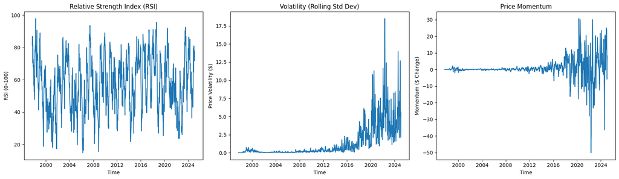

```python
fig, axs = plt.subplots(1, 3, figsize=(17, 5))  # Adjust size as needed
# Plot 1: RSI
axs[0].plot(data['rsi'])
axs[0].set_title("Relative Strength Index (RSI)")
axs[0].set_xlabel("Time")
axs[0].set_ylabel("RSI (0–100)")
# Plot 2: Volatility (7-day rolling std)
axs[1].plot(data['volatility_7'])
axs[1].set_title("Volatility (Rolling Std Dev)")
axs[1].set_xlabel("Time")
axs[1].set_ylabel("Price Volatility ($)")
# Plot 3: Momentum (7-day)
axs[2].plot(data['momentum_7'])
axs[2].set_title("Price Momentum")
axs[2].set_xlabel("Time")
axs[2].set_ylabel("Momentum ($ Change)")
plt.tight_layout()
plt.show()
```

```python
# Target: Priec direction, UP or DOWN (0, or 1)
y = data['Price_Direction']
# Features Selection
X = data[['volume', 'interest_rate', 'Interest_Rate_Change', 'price_range', 'rsi', 'volatility_7', 'momentum_7', '10Y_treasury_yield']]
# Combine, drop rows with any NaN in X or y
df_xandy = pd.concat([X, y.rename('target')], axis=1).dropna()

# Final cleaned X and y
X = df_xandy[X.columns]
y = df_xandy['target']
X
```

|  | volume | interest_rate | Interest_Rate_Change | price_range | rsi | volatility_7 | momentum_7 | 10Y_treasury_yield |
| --- | --- | --- | --- | --- | --- | --- | --- | --- |
| 1997-09-14 | 521640000 | 5.54 | 0.000000 | 0.059896 | 81.350551 | 0.020549 | 0.040430 | 6.29 |
| 1997-09-21 | 513624000 | 5.54 | 0.000000 | 0.051563 | 84.498664 | 0.033416 | 0.075911 | 6.09 |
| 1997-09-28 | 810408000 | 5.54 | 0.000000 | 0.043229 | 86.792809 | 0.041676 | 0.107161 | 6.08 |
| 1997-10-05 | 313320000 | 5.50 | -0.007220 | 0.034896 | 84.107284 | 0.037042 | 0.094010 | 6.01 |
| 1997-10-12 | 286296000 | 5.50 | 0.000000 | 0.026042 | 79.294887 | 0.022376 | 0.074153 | 6.15 |
| ... | ... | ... | ... | ... | ... | ... | ... | ... |
| 2025-01-05 | 114613100 | 4.33 | -0.033482 | 7.169998 | 75.507032 | 3.727797 | 18.357502 | 4.60 |
| 2025-01-12 | 121778800 | 4.33 | 0.000000 | 12.339996 | 71.680704 | 2.414580 | 4.352501 | 4.77 |
| 2025-01-19 | 150393100 | 4.33 | 0.000000 | 10.309998 | 73.351780 | 2.124446 | -5.840004 | 4.61 |
| 2025-01-26 | 133694800 | 4.33 | 0.000000 | 9.459991 | 75.991834 | 4.194694 | 5.052502 | 4.63 |
| 2025-02-02 | 185290300 | 4.33 | 0.000000 | 15.910004 | 77.728330 | 5.612252 | 8.180004 | 4.58 |

1430 rows × 8 columns

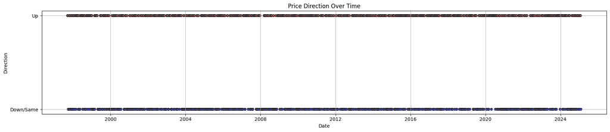

```python
plt.figure(figsize=(18, 4))
plt.scatter(y.index, y, c=y, cmap='bwr', edgecolors='k', s=20)
plt.title("Price Direction Over Time")
plt.xlabel("Date")
plt.ylabel("Direction")
plt.yticks([0, 1], ['Down/Same', 'Up'])
plt.grid(True)
plt.tight_layout()
plt.show()
```

Special care is required when splitting time-series data into training and testing sets. Unlike typical datasets, time-series data has a temporal structure that must be preserved to avoid data leakage. Using standard random splitting methods like train_test_split from scikit-learn would mix past and future data arbitrarily, potentially allowing the model to learn from future information when predicting the past—a scenario that undermines the integrity of the evaluation.

```python
from sklearn.preprocessing import StandardScaler

X = X.sort_index()
y = y.sort_index()
split_date = '2021-01-31'
X_train = X.loc[:split_date]
X_test = X.loc[split_date:]
y_train = y.loc[:split_date]
y_test = y.loc[split_date:]
```

# Primary Analysis

To evaluate the predictive power of each classification model, we used time-aware cross-validation via TimeSeriesSplit. This ensures that the temporal ordering of data is respected during training and validation—critical in time-series tasks like stock prediction, where future data must never inform past predictions. We evaluated each model using precision as the scoring metric, reflecting our emphasis on the reliability of positive predictions. Precision is especially relevant in financial applications where false positives (i.e., incorrect “buy” signals) can lead to unnecessary trades, transaction costs, or losses. Among all models tested, Gradient Boosting achieved the highest mean precision at 62.74%, with relatively low variance (±3.17%), indicating consistent performance across folds. Other strong performers included SVC (60.18%) and K-Nearest Neighbors (57.9%). These results suggest that models capable of capturing nonlinear relationships and local structure perform better in this context. Notably, models like Logistic Regression and Ridge Classifier performed less well, likely due to their linear assumptions. While precision alone doesn’t capture all aspects of model quality, it offers a practical lens through which to assess actionable predictions—favoring models that issue fewer but more trustworthy “buy” signals.

In the context of stock prediction, precision is a more meaningful metric than accuracy because the costs of different types of errors are highly asymmetric. A model with high accuracy might appear strong on paper by predicting “no movement” or “down” most of the time—especially if the data is skewed toward those outcomes—but such predictions are not necessarily useful for trading. What matters more is how often the model is correct when it actually signals a buy. This is where precision comes in: it measures the proportion of predicted upward movements that were actually correct. In trading, acting on a false positive (predicting an increase that doesn't happen) can result in direct financial loss, while a false negative (missing a real increase) may simply mean missed opportunity. Therefore, a model with high precision makes fewer predictions, but those it does make are more reliable and actionable. This focus on quality over quantity aligns much more closely with real-world trading strategies, where each decision carries risk, and trust in a model’s positive signal is critical.

```python
from sklearn.model_selection import TimeSeriesSplit, cross_val_score
from sklearn.linear_model import LogisticRegression, RidgeClassifier
from sklearn.ensemble import RandomForestClassifier, GradientBoostingClassifier, AdaBoostClassifier
from sklearn.tree import DecisionTreeClassifier
from sklearn.neighbors import KNeighborsClassifier
from sklearn.svm import SVC
from sklearn.neural_network import MLPClassifier
from sklearn.pipeline import make_pipeline
from sklearn.preprocessing import StandardScaler
from sklearn.linear_model import SGDClassifier

scaler = StandardScaler()
X_train_scaled = scaler.fit_transform(X_train)
X_test_scaled = scaler.transform(X_test)

# Time-aware cross-validation
tscv = TimeSeriesSplit(n_splits=2)

# Classification models
models = {
    'LogisticRegression': make_pipeline(StandardScaler(), LogisticRegression(max_iter=1000)),
    'RidgeClassifier': make_pipeline(StandardScaler(), RidgeClassifier()),
    'DecisionTree': make_pipeline(StandardScaler(), DecisionTreeClassifier(random_state=42)),
    'RandomForest': make_pipeline(StandardScaler(), RandomForestClassifier(random_state=42)),
    'GradientBoosting': make_pipeline(StandardScaler(), GradientBoostingClassifier(random_state=42)),
    'AdaBoost': make_pipeline(StandardScaler(), AdaBoostClassifier(random_state=42)),
    'KNeighbors': make_pipeline(StandardScaler(), KNeighborsClassifier(n_neighbors=5)),
    'SVC': make_pipeline(StandardScaler(), SVC(kernel='rbf', C=1.0, probability=True, random_state=42)),
    'SGDClassifier': make_pipeline(StandardScaler(), SGDClassifier(loss="modified_huber", penalty="l2", max_iter=100))
}

# Store accuracy scores
accuracy_results = []
print("Cross-Validated precision Scores:\n")

for name, model in models.items():
    scores = cross_val_score(model, X_train, y_train, cv=tscv, scoring='precision')
    mean_score = scores.mean()
    std_dev = scores.std()
    print(f"Name = {name:<17} Mean precision = {mean_score:>8.4f}   Std Dev = {std_dev:.4f}")
    accuracy_results.append({'Model': name, 'Mean precision': mean_score, 'Std precision': std_dev})

# Identify best model
best_model = max(accuracy_results, key=lambda x: x['Mean precision'])
print("\n------- Best Model by Cross-Validated precision -------")
print(f"{best_model['Model']} with precision = {best_model['Mean precision']:.4f}")
```

```
Cross-Validated precision Scores:

Name = LogisticRegression Mean precision =   0.5207   Std Dev = 0.0393
Name = RidgeClassifier   Mean precision =   0.5407   Std Dev = 0.0234
Name = DecisionTree      Mean precision =   0.5621   Std Dev = 0.0353
Name = RandomForest      Mean precision =   0.5613   Std Dev = 0.0032
Name = GradientBoosting  Mean precision =   0.6274   Std Dev = 0.0317
Name = AdaBoost          Mean precision =   0.5653   Std Dev = 0.0209
Name = KNeighbors        Mean precision =   0.5790   Std Dev = 0.0433
Name = SVC               Mean precision =   0.6018   Std Dev = 0.0018
Name = SGDClassifier     Mean precision =   0.5552   Std Dev = 0.0133

------- Best Model by Cross-Validated precision -------
GradientBoosting with precision = 0.6274
```

# Model Testing

This section of the project evaluates several machine learning models based on how well they predict the direction of Amazon’s stock, with a focus on precision as the primary metric. Precision measures how often the model's predictions of an "up" movement are actually correct, which is particularly important in financial contexts—executing a bad "buy" trade is far more costly than missing a profitable one. Each model is trained on standardized data and tested using the same feature set. The evaluation includes both the precision score for the positive class (i.e., predicted "up") and a weighted average precision that considers performance across both classes (up and down), accounting for class imbalance.

From the results, the Support Vector Classifier (SVC) achieved the highest positive-class precision at 0.550, meaning that when it predicted an upward price movement, it was correct 55% of the time. Other models like Gradient Boosting, Random Forest, and SGDClassifier performed similarly, hovering around the 48–51% precision range. While these numbers may seem modest, they are significant given the inherent noise and unpredictability of financial markets. Precision is prioritized over accuracy in this analysis because it better reflects the cost structure of real-world trading: false positives lead to poor trades, whereas false negatives merely represent missed opportunities.

While cross-validation provides a strong estimate of a model’s expected performance, its results can differ from final evaluation scores when the model is tested on unseen data. In our case, GradientBoosting showed the highest average precision during cross-validation (62.7%), but dropped to 51.2% on the test set. Similar declines are seen across other models.

This is not necessarily a flaw in the modeling process—it reflects the inherent unpredictability of stock market data. Stock movements are influenced by many external factors such as earnings announcements, interest rate changes, and market sentiment shifts. These events can create volatility in the test period that was not present in the training data.

As a result, models trained on relatively stable or structured patterns may struggle when exposed to more volatile, less predictable conditions in the test set. In other words, the market behavior captured in the training set may differ meaningfully from that in the test set.

This outcome emphasizes the importance of evaluating models in real-world scenarios, and of interpreting metrics like precision with an understanding of market variability. While we can optimize for performance, some degree of unpredictability will always remain in financial data.

```python
from sklearn.metrics import precision_score, classification_report
from sklearn.preprocessing import StandardScaler

# Scale features
scaler = StandardScaler()
X_train_scaled = scaler.fit_transform(X_train)
X_test_scaled = scaler.transform(X_test)

# Store results for comparison
model_results = []

# Train each model
for name, model in models.items():
    model.fit(X_train_scaled, y_train)  # <-- Classification target

# Evaluate models
print("\nModel Evaluation Results:\n")
for model_name, model in models.items():
    y_pred = model.predict(X_test_scaled)

    # precision accuracy
    score = precision_score(y_test, y_pred, zero_division=0)
    report_text = classification_report(y_test, y_pred, output_dict=True)
    report_summary = {
      'positive_precision': round(score, 4),
      'weighted_precision': round(report_text['weighted avg']['precision'], 4),
      'recall': round(report_text['weighted avg']['recall'], 4),
      'f1-score': round(report_text['weighted avg']['f1-score'], 4)
    }

    # Store results
    model_results.append({
        'name': model_name,
        'score': score,  # used for comparison
        'report': report_summary,
        'model': model
    })

    print(f"precision score of {model_name}: {score:.3f}")
    print(f"Classification Report for {model_name}:\n{report_summary}")

# Find the best model by Accuracy
best_model = max(model_results, key=lambda x: x['score'])

# Final output
print("\n------- Most Precise Model: -------")
print(f"{best_model['name']} with precision = {best_model['score']:.3f}")
print("Classification Report:\n", best_model['report'])

# Save for later use
best_model_info = best_model
```

```
Model Evaluation Results:

precision score of LogisticRegression: 0.485
Classification Report for LogisticRegression:
{'positive_precision': 0.4847, 'weighted_precision': 0.4255, 'recall': 0.4571, 'f1-score': 0.412}
precision score of RidgeClassifier: 0.487
Classification Report for RidgeClassifier:
{'positive_precision': 0.4875, 'weighted_precision': 0.4358, 'recall': 0.4619, 'f1-score': 0.422}
precision score of DecisionTree: 0.406
Classification Report for DecisionTree:
{'positive_precision': 0.4062, 'weighted_precision': 0.4324, 'recall': 0.4524, 'f1-score': 0.3784}
precision score of RandomForest: 0.506
Classification Report for RandomForest:
{'positive_precision': 0.5057, 'weighted_precision': 0.4893, 'recall': 0.4857, 'f1-score': 0.4821}
precision score of GradientBoosting: 0.512
Classification Report for GradientBoosting:
{'positive_precision': 0.5124, 'weighted_precision': 0.4929, 'recall': 0.4952, 'f1-score': 0.4925}
precision score of AdaBoost: 0.450
Classification Report for AdaBoost:
{'positive_precision': 0.45, 'weighted_precision': 0.4347, 'recall': 0.4333, 'f1-score': 0.4332}
precision score of KNeighbors: 0.461
Classification Report for KNeighbors:
{'positive_precision': 0.4609, 'weighted_precision': 0.4367, 'recall': 0.4381, 'f1-score': 0.437}
precision score of SVC: 0.550
Classification Report for SVC:
{'positive_precision': 0.55, 'weighted_precision': 0.5366, 'recall': 0.5381, 'f1-score': 0.5359}
precision score of SGDClassifier: 0.500
Classification Report for SGDClassifier:
{'positive_precision': 0.5, 'weighted_precision': 0.4897, 'recall': 0.481, 'f1-score': 0.392}

------- Most Precise Model: -------
SVC with precision = 0.550
Classification Report:
 {'positive_precision': 0.55, 'weighted_precision': 0.5366, 'recall': 0.5381, 'f1-score': 0.5359}
```

# Model Prediction Visualizations

Visualization 1: Feature Importance for SVC Model (Permutation-Based) This plot shows which features were most important to the SVC model’s predictions. Since SVC with an RBF kernel is a nonlinear model, we can’t directly look at internal weights or coefficients like we would with a linear model. Instead, we used a method called permutation importance, which checks how much worse the model performs when each feature is scrambled. If messing up a feature causes a big drop in precision, that feature was clearly important.

Each bar in the chart represents one feature. The longer the bar, the more the model relied on that feature to make accurate predictions. The horizontal error bars show how consistent the results were across different random shuffles—shorter error bars mean the importance is more stable.

This method gives us a way to peek inside a model that normally doesn’t offer much interpretability. It helps us understand which features the model is paying attention to when it predicts an upward price movement. If a feature is very influential, we might want to examine it more closely to make sure it makes sense. If a feature barely matters, it might be safe to drop it in future versions of the model.

For models like SVC that operate in a high-dimensional, nonlinear space, this kind of post-hoc analysis is one of the few ways to get a read on what’s actually driving predictions.

To read more: https://scikit-learn.org/stable/modules/permutation_importance.html

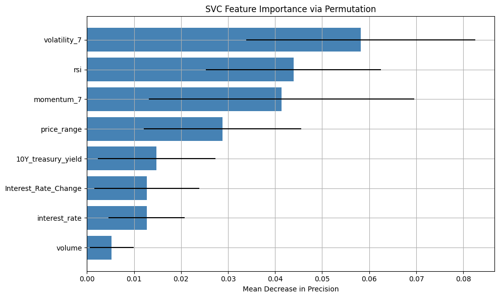

```python
from sklearn.inspection import permutation_importance
# Pull out best model and re-predict on scaled test set
best_model['model'].fit(X_train, y_train)

# Run permutation importance on test set
perm_result = permutation_importance(
    best_model['model'], X_test, y_test, scoring='precision', n_repeats=30, random_state=42
)

# Create a DataFrame for plotting
perm_df = pd.DataFrame({
    'Feature': X.columns,
    'Importance': perm_result.importances_mean,
    'Std': perm_result.importances_std
}).sort_values(by='Importance', ascending=True)

# Plot the feature importances
plt.figure(figsize=(10, 6))
plt.barh(perm_df['Feature'], perm_df['Importance'], xerr=perm_df['Std'], color='steelblue')
plt.xlabel("Mean Decrease in Precision")
plt.title(f"{best_model['name']} Feature Importance via Permutation")
plt.grid(True)
plt.tight_layout()
plt.show()
```

Visualization 2: Actual vs Predicted Stock Price Directions This visualization compares the model’s predictions against the actual stock price directions over the test period. On the x-axis are the weeks in the test dataset, while the y-axis shows the direction of price movement: 0 indicates the stock moved down or stayed flat, and 1 indicates it moved up. Each blue circle represents the actual observed direction, and each red “x” marks the prediction made by the best-performing classification model.

The purpose of this plot is to provide a visual check on how well the model is performing. It makes patterns (or mismatches) between predicted and actual directions immediately obvious. Clusters of correct predictions (where red and blue points overlap) indicate good model alignment with the market. Gaps or misaligned patterns suggest potential issues with the model’s sensitivity or generalization. Unlike metrics like accuracy or precision, this plot reveals when and where the model gets it wrong—critical context for trading strategies based on these signals.

```
 Plotting for Best Model: SVC
```

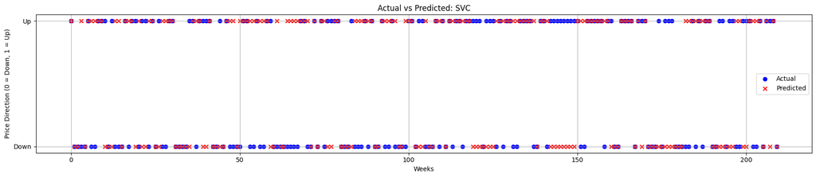

```python
import matplotlib.pyplot as plt
from sklearn.metrics import classification_report

# Get the best model (already computed earlier)
best_model_name = best_model['name']
print(f"\n Plotting for Best Model: {best_model_name}")

# Retrieve the model object from your models dictionary
best_model_object = models[best_model_name]

# Predict again using the best model (optional if not already done)
y_pred = best_model_object.predict(X_test)

plt.figure(figsize=(18, 4))
plt.scatter(range(len(y_test)), y_test, label='Actual', marker='o', c='blue')
plt.scatter(range(len(y_pred)), y_pred, label='Predicted', marker='x', c='red')
plt.title(f"Actual vs Predicted: {best_model_name}")
plt.xlabel("Weeks")
plt.ylabel("Price Direction (0 = Down, 1 = Up)")
plt.yticks([0, 1], ['Down', 'Up'])
plt.legend()
plt.grid(True)
plt.tight_layout()
plt.show()
```

# Practical approach to implementing the model: A demonstration.

This trading strategy simulates how an investor might act based on the predictions of the best-performing classification model. The model forecasts whether Amazon's stock will go up (1) or down/stay (0) in the next time period. Using these predictions, the strategy decides when to buy, sell, or hold the stock. If the model predicts an upward movement and the investor is not currently holding any stock, the strategy initiates a buy. If the model predicts a decline and the investor is holding stock, it sells. Otherwise, it holds the current position. The investor begins with a fixed amount of capital—$1000 (chosen arbitrarily)—and the strategy tracks how that capital changes over time as trades are made.

Having a trading strategy is essential because predictions alone are not enough to evaluate a model's effectiveness. A model may be statistically accurate, but unless its predictions translate into profitable trades, it holds little real-world value. This strategy provides a framework to operationalize the model’s outputs, simulating actual decisions an investor would make. It also highlights the importance of timing, risk, and compounding effects over time. By applying this logic to the best model, we test whether the model’s classification accuracy leads to tangible financial gains, and we evaluate its performance in terms of capital growth, not just predictive score. This bridges the gap between theoretical performance and practical utility in financial forecasting.

```
Final simulated capital: $ 1395.02

Trading Log:
          Date        Action  PrevPrice  ActualPrice  Prediction  Capital
0   2021-02-07           BUY     160.31       167.61           1  1045.52
1   2021-02-14          SELL     167.61       163.89           0     0.00
2   2021-02-21          HOLD     163.89       162.49           0  1045.52
3   2021-02-28           BUY     162.49       154.65           1   995.02
4   2021-03-07          SELL     154.65       150.02           0     0.00
..         ...           ...        ...          ...         ...      ...
204 2025-01-05          HOLD     223.75       224.19           1  1335.70
205 2025-01-12          SELL     224.19       218.94           0     0.00
206 2025-01-19           BUY     218.94       225.94           1  1378.41
207 2025-01-26          SELL     225.94       234.85           0     0.00
208 2025-02-02  SELL (final)     234.85       237.68           1  1395.02

[209 rows x 6 columns]
```

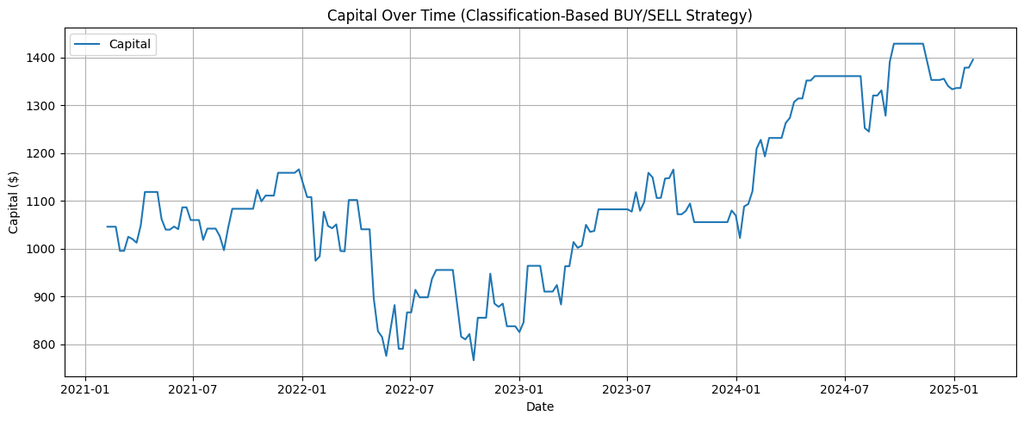

```python
# Get best classification model
best_model_info = max(model_results, key=lambda x: x['score'])  # score = accuracy
fitted_model = best_model_info['model']

# Predict price direction (1 = up, 0 = down/stay)
y_pred = fitted_model.predict(X_test)

# Actual close prices
# Ensure X_test.index aligns with the rows in X_test and y_pred
actual_prices = data.loc[X_test.index, 'close']

# Ensure y_pred and actual_prices have compatible lengths for the loop
# The loop uses y_pred[i-1] and actual_prices.iloc[i]
# If len(y_pred) == len(actual_prices), then y_pred[k] is for period k to k+1.
# The loop range(1, len(y_pred)) will process len(y_pred)-1 periods.
# This means predictions y_pred[0]...y_pred[len(y_pred)-2] are used.
# And prices actual_prices.iloc[0]...actual_prices.iloc[len(y_pred)-1] are used.

# Trading simulation parameters
capital = 1000.0
in_position = False
shares = 0
positions = []  # To store capital at each step
log = []

# Loop through each week (or time period)
# The loop processes len(y_pred) - 1 potential trades if y_pred has same length as actual_prices considered for decision making.
# Or more generally, it processes N-1 periods if N is the number of elements in y_pred.
# y_pred[k] is the prediction for the interval starting after actual_prices.iloc[k]
# No, y_pred[k] is the prediction for the interval from actual_prices.iloc[k] to actual_prices.iloc[k+1]
# So y_pred[i-1] is prediction for interval actual_prices.iloc[i-1] to actual_prices.iloc[i]

for i in range(1, len(actual_prices)): # Iterate based on number of price points allowing for prev/current
    if i > len(y_pred): # Ensure we don't run out of predictions
        break

    prev_price = actual_prices.iloc[i - 1]
    actual_price = actual_prices.iloc[i]
    # Prediction y_pred[i-1] corresponds to the expected movement from prev_price to actual_price
    predicted_direction = y_pred[i - 1]  # 1 = BUY, 0 = SELL/HOLD
    action = "HOLD"
    current_period_value = capital # Default if not in position

    # --- BUY if predicted to go UP and not already holding ---
    if not in_position and predicted_direction == 1:
        if prev_price > 0: # Avoid division by zero or buying with no price
            shares = capital / prev_price
            capital = 0
            in_position = True
            action = "BUY"

    # --- SELL if predicted to go DOWN and currently holding ---
    elif in_position and predicted_direction == 0:
        capital = shares * prev_price # Sell at the price before the predicted drop
        shares = 0
        in_position = False
        action = "SELL"

    # --- Update current capital position ---
    if in_position:
        current_period_value = shares * actual_price
        positions.append(current_period_value)
    else:
        positions.append(capital) # Already current_period_value

    log.append({
        'Date': actual_prices.index[i], # Date of actual_price (end of period)
        'Action': action,
        'PrevPrice': round(prev_price, 2),
        'ActualPrice': round(actual_price, 2),
        'Prediction': int(predicted_direction),
        'Capital': round(current_period_value, 2)
    })

# Final status: sell if still in position using the very last available price
if in_position and len(actual_prices) > 0:
    final_price = actual_prices.iloc[-1]
    if final_price > 0 : # Ensure valid price for selling
        capital = shares * final_price
        shares = 0
        in_position = False

        # Update the last recorded position value
        if positions: # Ensure positions list is not empty
            positions[-1] = capital

        # Update the last log entry for the final sell
        if log: # Ensure log is not empty
            log[-1]['Action'] = 'SELL (final)'
            # The 'ActualPrice' in the log for the period where the decision to hold was made
            # might be different from final_price if the simulation ended mid-period.
            # For clarity, the final action's impact is on the 'Capital' field.
            # We can also update the 'ActualPrice' in the log to final_price IF the last log entry
            # corresponds to the very last period.
            if log[-1]['Date'] == actual_prices.index[-1]:
                 log[-1]['ActualPrice'] = round(final_price, 2)
            log[-1]['Capital'] = round(capital, 2)

# Final report
print("Final simulated capital: $", round(capital, 2))

# Create and display trading log
trade_log = pd.DataFrame(log)
print("\nTrading Log:")
print(trade_log)

# Plot capital over time
if not trade_log.empty:
    plt.figure(figsize=(12, 5))
    plt.plot(trade_log['Date'], positions, label='Capital') # positions should be same length as trade_log['Date']
    plt.title("Capital Over Time (Classification-Based BUY/SELL Strategy)")
    plt.xlabel("Date")
    plt.ylabel("Capital ($)")
    plt.grid(True)
    plt.legend()
    plt.tight_layout()
    plt.show()
else:
    print("\nNo trades or periods to plot.")
```

# Baseline for comparison

This baseline strategy, often referred to as the “hold” or “buy-and-hold” approach, simulates the outcome of purchasing Amazon stock at the beginning of the test period and holding it without making any further trades. The investor starts with a fixed amount of capital—$1000—and uses it to buy as many shares as possible on the first day of the test window. After that, no further buying or selling is done; the strategy simply tracks the value of those shares over time based on the changing stock price.

Each week (or time period), the current value of the investment is recorded, reflecting how the price of the held asset changes. At the end of the test period, the strategy sells all remaining shares at the final available price to determine the ending capital. This provides a clear and stable benchmark against which other, more complex strategies can be evaluated.

The importance of this baseline lies in its simplicity and reliability. It makes no assumptions, relies on no predictions, and avoids overtrading—minimizing transaction costs and risk exposure to model error. If a model-driven strategy fails to outperform this passive approach, it suggests that the model is adding complexity without delivering real value. Comparing machine learning-based trading strategies to this baseline helps contextualize their performance and underscores whether the added sophistication translates into actual financial gain.

```
Final capital from HOLD strategy: $ 1482.63
```

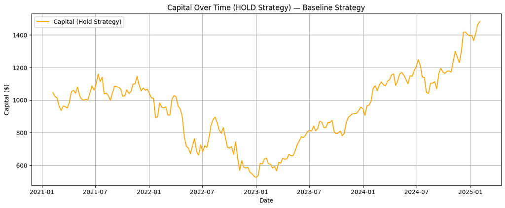

```python
# Actual closing prices for the test period
actual_prices = data.loc[X_test.index, 'close']

# --- HOLD Strategy Simulation ---
capital = 1000.0
positions = []
log = []

# Buy on the first day of the test period
buy_price = actual_prices.iloc[0]
shares = capital / buy_price
capital = 0

# Simulate holding the asset over the test period
for i in range(1, len(actual_prices)):
    current_price = actual_prices.iloc[i]
    current_date = actual_prices.index[i]
    current_value = shares * current_price

    positions.append(current_value)
    log.append({
        'Date': current_date,
        'Action': "HOLD",
        'BuyPrice': round(buy_price, 2),
        'CurrentPrice': round(current_price, 2),
        'Capital': round(current_value, 2)
    })

# Final sell at the end of the test period
final_price = actual_prices.iloc[-1]
capital = shares * final_price
shares = 0
positions[-1] = capital
log[-1]['Action'] = "SELL (final)"

# Final report
print("Final capital from HOLD strategy: $", round(capital, 2))

# Convert log to DataFrame
trade_log = pd.DataFrame(log)

# Plot only the capital over time as points
plt.figure(figsize=(12, 5))
plt.plot(trade_log['Date'], positions, label='Capital (Hold Strategy)', color='orange')
plt.title("Capital Over Time (HOLD Strategy) — Baseline Strategy")
plt.xlabel("Date")
plt.ylabel("Capital ($)")
plt.grid(True)
plt.legend()
plt.tight_layout()
plt.show()
```

# Conclusion

This project explores the use of machine learning to predict the direction of Amazon’s stock price movements. It is designed to be accessible to readers unfamiliar with financial modeling, while still providing technical depth for those with experience in data science or quantitative finance. It lays out the data sources, modeling strategies, and predictive outcomes in a structured and interpretable way.

Our analysis shows that while classification-based machine learning models can identify certain patterns in historical stock data, financial markets remain fundamentally resistant to precise modeling. They are not merely noisy—they are adversarial, reflexive, and constantly evolving. Even our most carefully engineered models underperformed compared to a simple buy-and-hold strategy. For example, an investor who placed 1000 dollars in the SP 500 in 2021 would have seen their portfolio grow to nearly 1500 dollars by 2025, a return that significantly exceeds what our model-driven approach achieved.(https://www.officialdata.org/us/stocks/s-p-500/2021?amount=1000&endYear=2025).

This is not a failure of machine learning per se, but a reflection of the limits of prediction in financial domains. Unlike physics or engineering systems, markets are shaped by behavior, feedback loops, regulatory shifts, and black swan events. Predictive accuracy alone is not enough; robustness, adaptability, and interpretability matter just as much—if not more.

That said, this work does demonstrate the value of data science in finance. The process of cleaning data, constructing features, validating models, and visualizing outcomes provides tangible insights into how the market behaves—and how it often defies systematic forecasting. The tools used here can be extended, improved, and integrated with broader financial signals such as sentiment data, macroeconomic indicators, or event-driven news pipelines.

In the end, this project is not a proof of machine learning supremacy in trading, but rather a case study in its pragmatic utility. Data science can illuminate, clarify, and guide—but it cannot remove uncertainty. In a domain as complex and dynamic as financial markets, it is a tool—not an oracle.

# Future Directions & Insights:

In the future, incorporating more financial theory—particularly concepts related to risk—could help improve the model’s predictive accuracy. We also see potential in using Hamiltonian Monte Carlo (HMC) methods to better classify market regimes, such as identifying whether the current environment is a bull or bear market. Training separate models for each market condition could significantly enhance overall performance. Additionally, developing more refined trading strategies around the model’s predictions could lead to greater profitability in real-world scenarios. Finally, we aim to explore how to build a more generalizable model—one that can reliably predict the direction of any stock, provided it has access to enough historical data.

To keep the simulation simple and focused on model performance, we did not include trading fees, slippage, or taxes—costs that can significantly impact real-world profitability. Ignoring these factors makes it easier to test algorithmic strategies in isolation, but we recognize that they are critical to evaluating practical success. In future work, we plan to incorporate these variables into our simulation to develop more robust strategies that can remain profitable after accounting for real-world trading costs.

This project set out to explore whether machine learning can be used to predict stock movements and develop viable trading strategies. The answer is: yes—but not easily. While the models presented here demonstrate that predictive signals do exist, the path from prediction to profit is filled with complexity. Furthermore, we would like to test this model with more features such as 'open' price in the future. We have decided to not include it in this case to focus more on indicators. In that vein, we also could have used more indicators, but chose to stick with simple indicators. In the future, we would also like to test this model with more nuanced and complicated technical indicators, as well as different economic data.

Real markets are noisy, non-stationary, and often irrational. Success in this space requires not just good models, but also:

- Smart feature engineering rooted in financial theory,
- Robust validation methods to avoid overfitting,
- And a healthy dose of skepticism when interpreting results.

This project does not claim to have found a "silver bullet,” but it does show what’s possible with persistence, discipline, and the right tools. If nothing else, we hope it demonstrates that trading with ML is not just possible, but it is also an excellent way to learn about both data science and the financial world.